# Exercises - Bayes Rules! 3

## Exercise 3.13

```r
## we want  a mean of ~.475

1/alfa(mean = .475)
```

```
## [1] 1.105263
```

```r
# beta = 1.1

quantile(rbeta(1000, 29, 28), c(.05,.95)) ## Fairly close
```

```
##        5%       95%
## 0.4026184 0.6139574
```

```r
summarize_beta(29,28)
```

```
##        mean      mode         var         sd
## 1 0.5087719 0.5090909 0.004309018 0.06564311
```

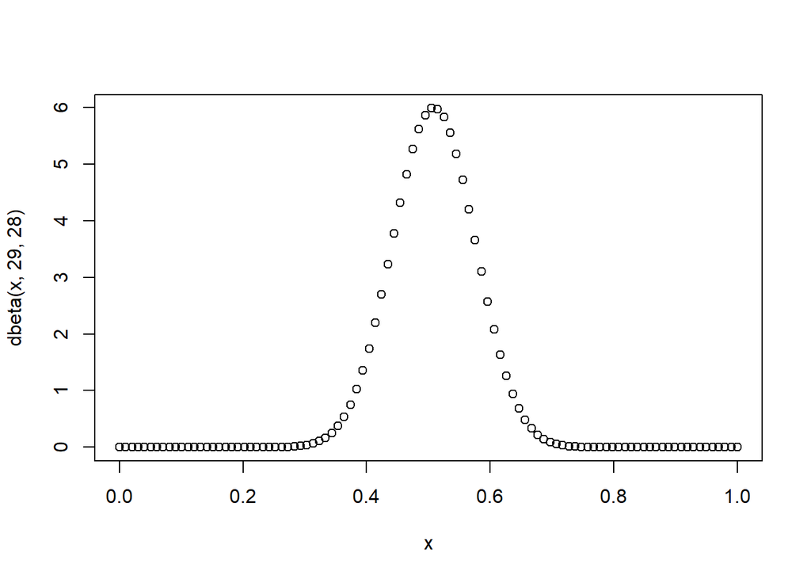

```r
x <- seq(0,1,length.out=100) # all possible x values
plot(x,dbeta(x,29,28))
```

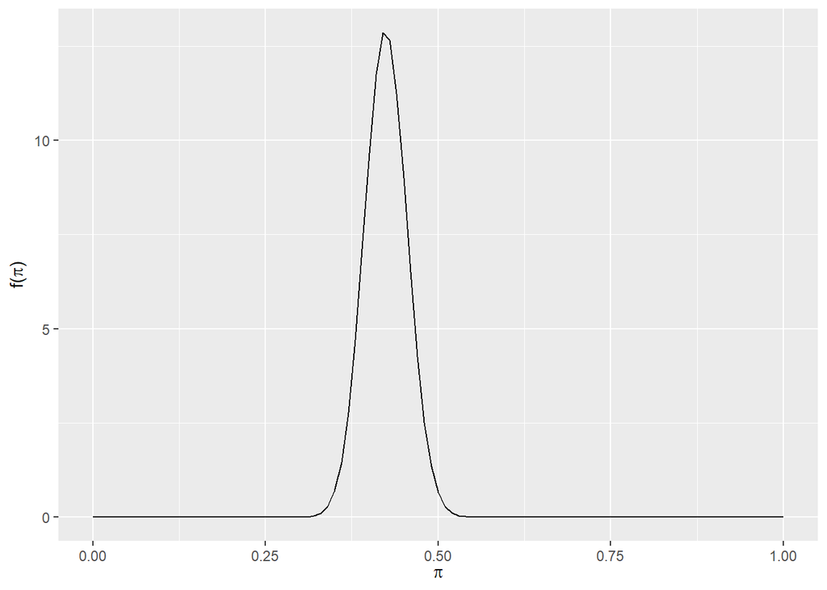

```r
## we want  a mean of ~.475


plot_beta(29+80,28+200-80)
```

```r
summarize_beta_binomial(29,28,80,200)
```

```
##       model alpha beta      mean      mode          var         sd
## 1     prior    29   28 0.5087719 0.5090909 0.0043090182 0.06564311
## 2 posterior   109  148 0.4241245 0.4235294 0.0009466779 0.03076813
```

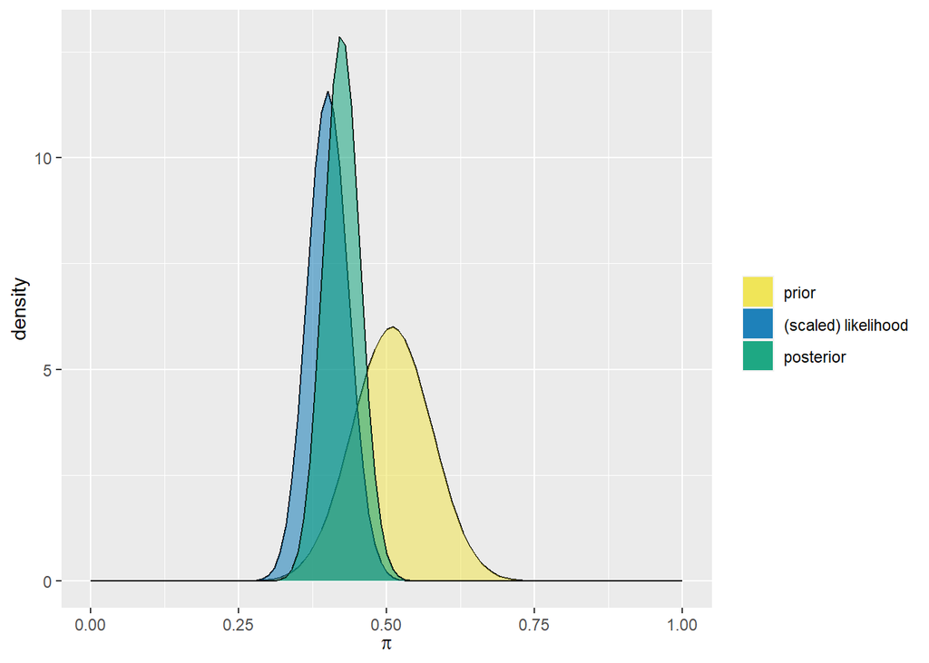

```r
plot_beta_binomial(29,28,y = 80,200)
```

Sylvia overestimated the percent of people who know someone who is transgender in her prior belief, and she also gave it a long range. After the survey, the updated prior reflects that a less proportion of people knew someone who is transgender, and that this percentage does not vary that much. In this case the data outweighed the prior.

## Exercise 3.14

Write the corresponding input code for the summarize_beta_binomial() output below.

My thought process was this: if the prior mean was 40% and the posterior mean 31%, then the proportion observed (y/n) must be lower than 31%, so I suspected something around 25%, say 1/4.

```r
summarize_beta_binomial(2,3,1,4)
```

```
##       model alpha beta      mean      mode        var        sd
## 1     prior     2    3 0.4000000 0.3333333 0.04000000 0.2000000
## 2 posterior     3    6 0.3333333 0.2857143 0.02222222 0.1490712
```

Posterior SD and alphas and betas are too small in contrast to these. I suspected there should be a higher pair of numbers fitted to that proportion (~25%), so after several attempts I got to this which closely matches that of the book:

```r
summarize_beta_binomial(2,3,9,36)
```

```
##       model alpha beta      mean      mode         var         sd
## 1     prior     2    3 0.4000000 0.3333333 0.040000000 0.20000000
## 2 posterior    11   30 0.2682927 0.2564103 0.004674089 0.06836731
```

## Exercise 3.15

Since the posterior mean is very close to 1, the proportion in the likelihood model must have been close to 100%. The sd is small, so numbers must be high.

```r
summarize_beta_binomial(1,2,99,100)
```

```
##       model alpha beta      mean     mode          var         sd
## 1     prior     1    2 0.3333333 0.000000 0.0555555556 0.23570226
## 2 posterior   100    3 0.9708738 0.980198 0.0002719027 0.01648947
```

## Exercise 3.16

1. The prior was very confident that the probability of x thing was close to 1. However, new data challenged that, as shown in the pdf of the likelihood function. In the trial, the mean probability of success was close to .25, but with much more variability.
2. The posterior model is closer to the prior, because it had less variation than the one in the observed data. Data pulled the posterior closer to the prior.

```r
# We know prior's mean is 1, so
alfa(.98) # alfa is ~49 times b
```

```
## [1] 49
```

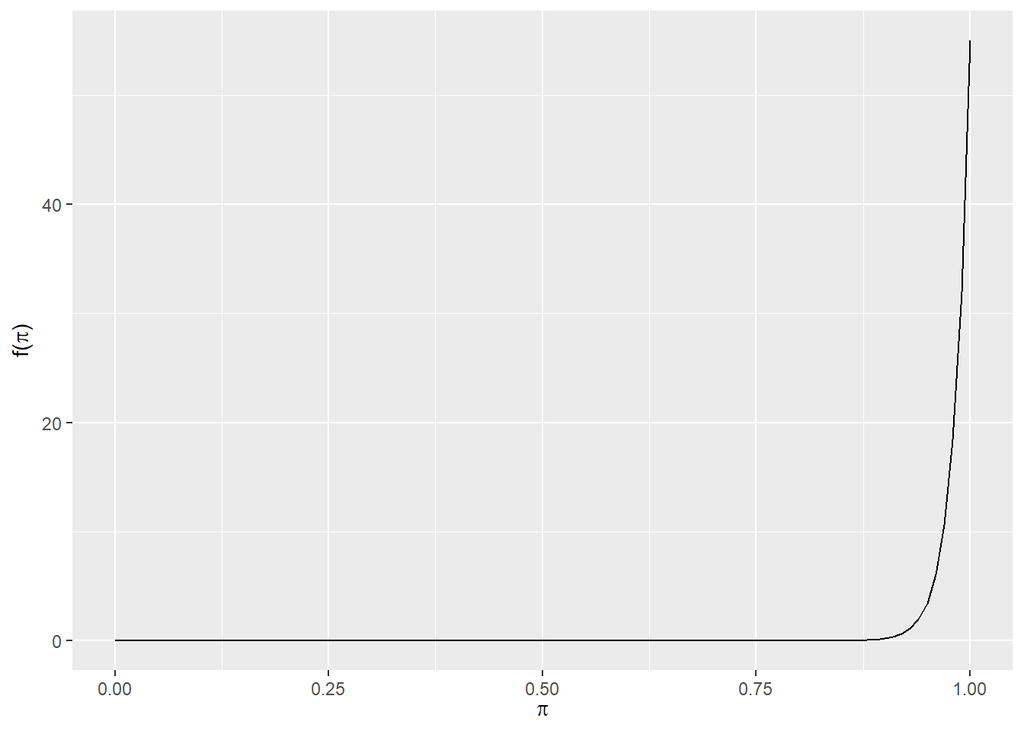

```r
plot_beta(55,1)
```

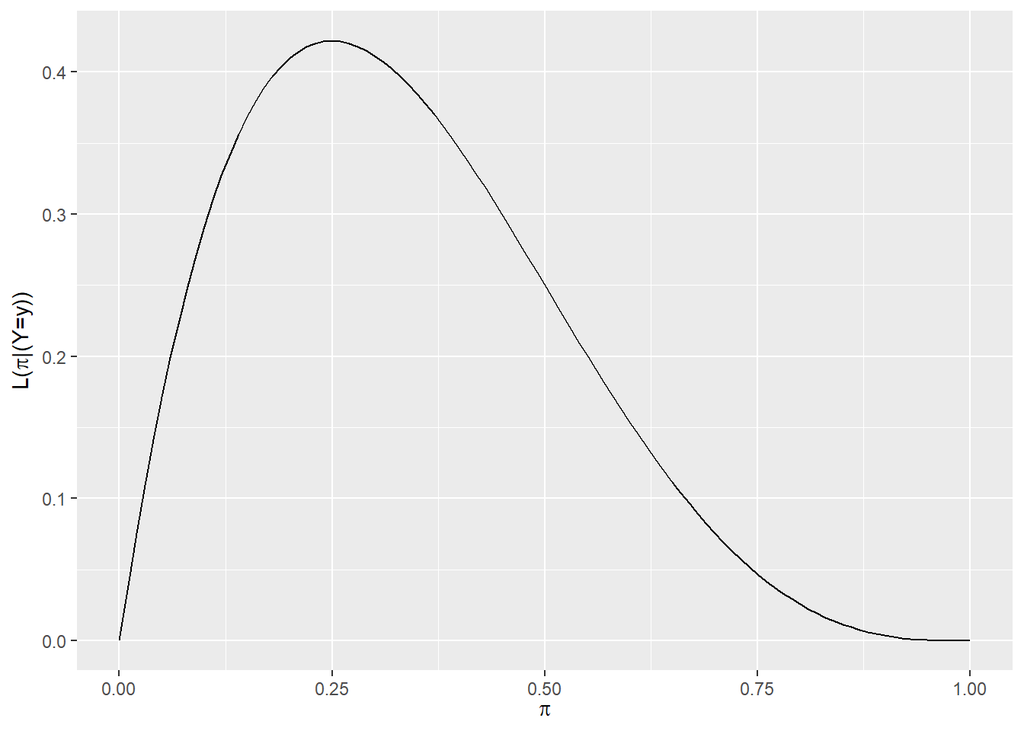

```r
# We know that the mean around the likelihood function is .25 and that the distrrbution is very spread, so we dont have a lot of data i.e., n=small

plot_binomial_likelihood(1,4)
```

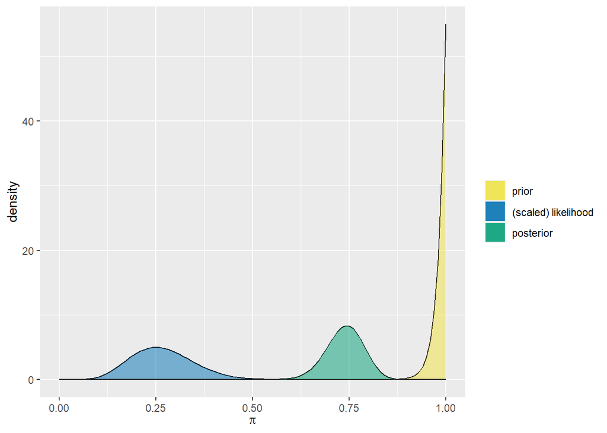

```r
plot_beta_binomial(55,1,7,28)
```

## Exercise 3.17

1. The prior distribution is very wide, so in contrast to the one in 3.16 there is much less certainty. In contrast also to the preivous exercise the observed data is more robus, as seen by the low SD of the likelihood function.
2. The posterior model is closer to the data (as reflected by the likelihood function)! This is because the prior was too vague. The observed data outweighed the prior model.

```r
# We know prior's mean is .5, so
alfa(.5) # alfa is ~1 times b, and we also have a wide variation so the relation between alfa and beta must be based on small numbers
```

```
## [1] 1
```

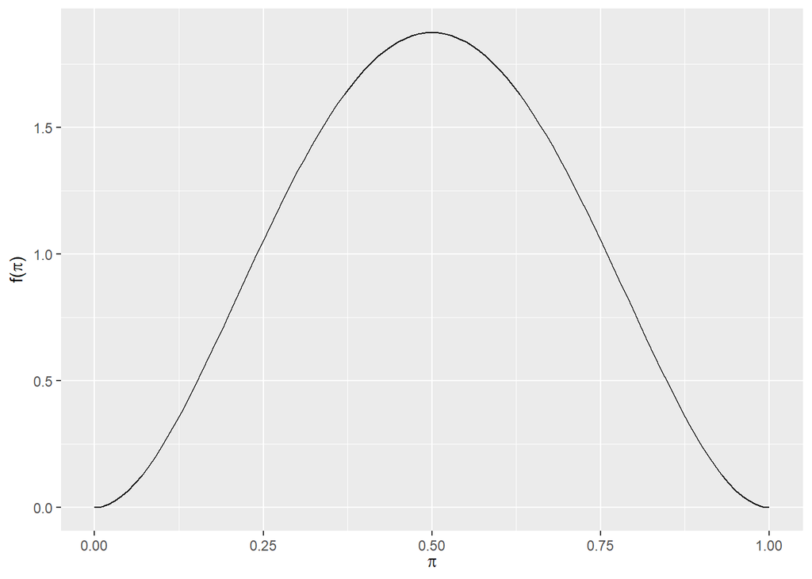

```r
plot_beta(3,3)
```

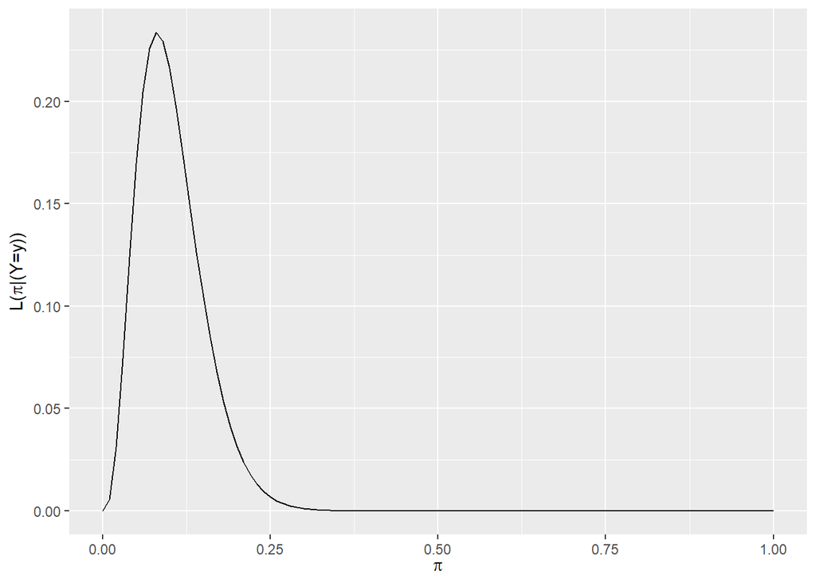

```r
# We know that the mean around the likelihood function is .12 and that the distrrbution is not very spread, so we may have a lot of data i.e., n=medium-large

plot_binomial_likelihood(3,37)
```

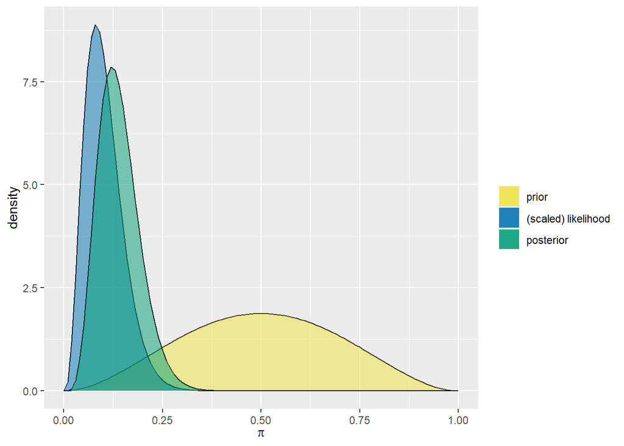

```r
plot_beta_binomial(3,3,3,37)
```

## Exercise 3.18

```r
summarize_beta_binomial(3,3,30,40)
```

```
##       model alpha beta      mean      mode         var        sd
## 1     prior     3    3 0.5000000 0.5000000 0.035714286 0.1889822
## 2 posterior    33   13 0.7173913 0.7272727 0.004313639 0.0656783
```

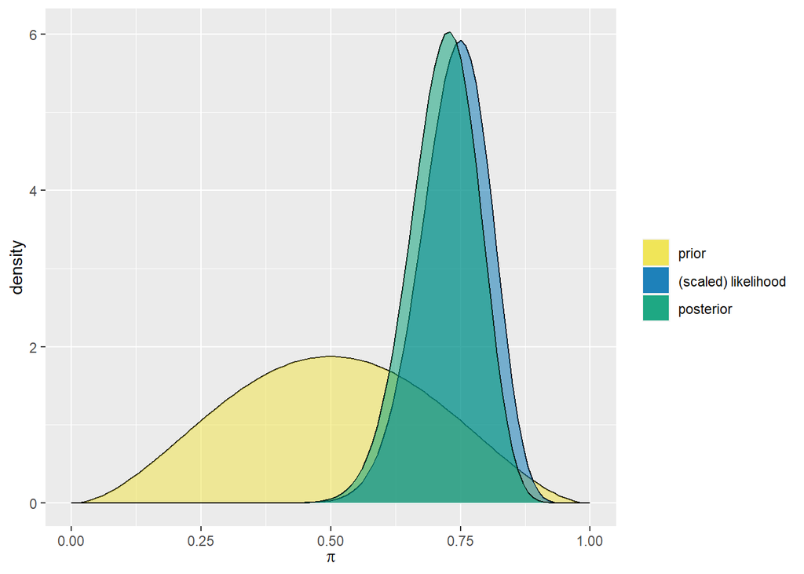

```r
plot_beta_binomial(3,3,30,40)
```

```r
summarize_beta_binomial(3,3,15,20)
```

```
##       model alpha beta      mean      mode         var         sd
## 1     prior     3    3 0.5000000 0.5000000 0.035714286 0.18898224
## 2 posterior    18    8 0.6923077 0.7083333 0.007889546 0.08882312
```

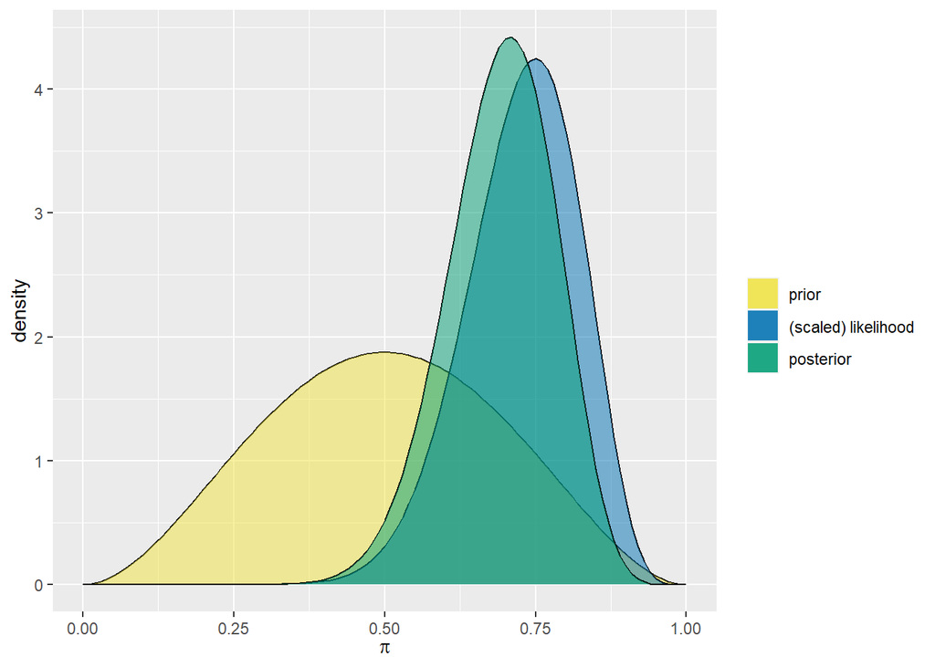

```r
plot_beta_binomial(3,3,15,20)
```

3. Both models are similar in every sense. The only difference is that Patrick’s likelihood function is closer to the posterior model than Harold’s. The reason is that Patrick use a larger sample to update his prior (n=40). By using a smaller sample, Harold’s posterior model is closer to his prior.